# Unsupervised Learning

#### Petal Length vs Petal Width BY Species (color)

So, let’s now add color so we can see how the different species of flower cluster together (or not).

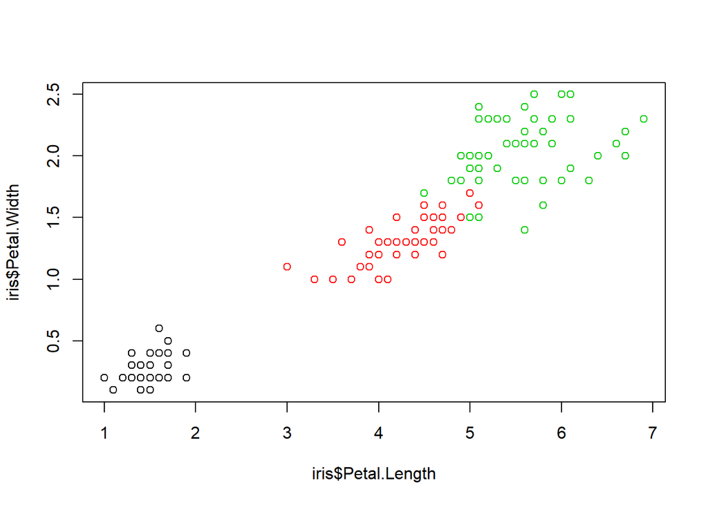

```r
plot(iris$Petal.Length, iris$Petal.Width,
     col = iris$Species)
```

### Matrix Scatterplot

Using the `car` package, make a `scatterplotMatrix()` to see all 2D bivariate scatterplots at once.

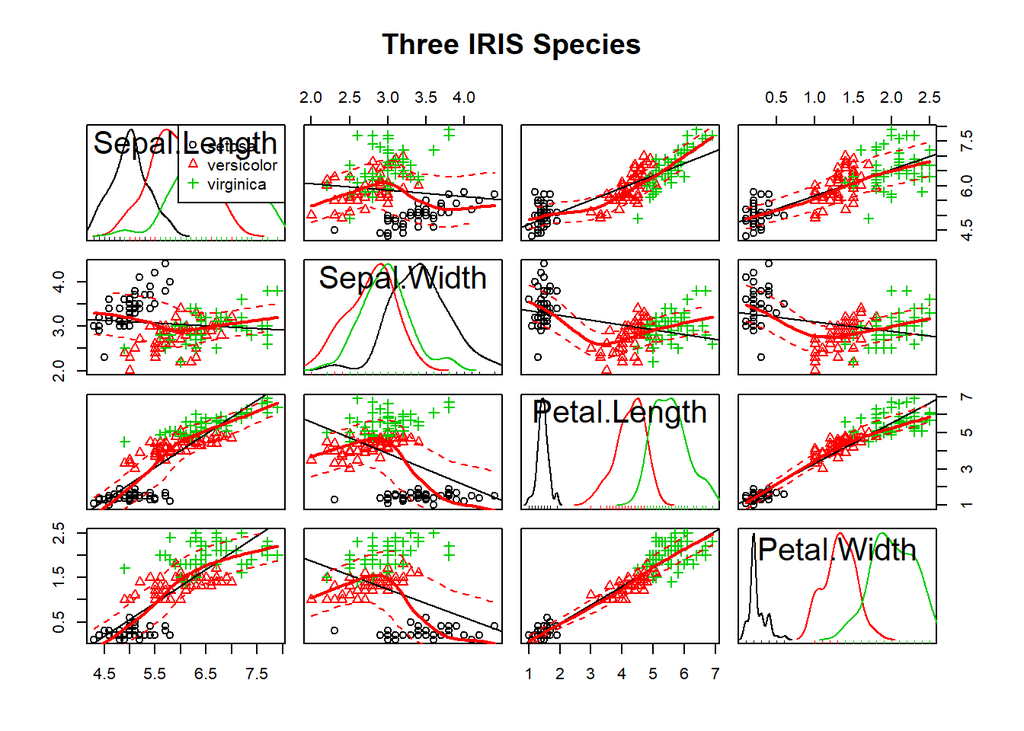

```r
library(car)
car::scatterplotMatrix(~Sepal.Length+Sepal.Width+Petal.Length+Petal.Width|Species,
                   data=iris,
                   main="Three IRIS Species")
```

### Cluster Analysis of the IRIS Dataset

Let’s use the `hclust()` function to run a cluster analysis of the `iris` dataset - letting the software algorithm create the clusters - this is done WITHOUT knowledge that there are (should be) 3 clusters based on the 3 species of flowers.

We’ll run the cluster analysis, which defaults to the “complete” linkage algorithm *(aka. “agglomeration method”)* to compute the distances (similarity or dissimilarity) between the samples.

Next we use this result to make a plot called a “dendogram”.

```r
clusters <- hclust(dist(iris[,1:4]))
```

#### Dendogram Cluster Analysis - Complete Linkage

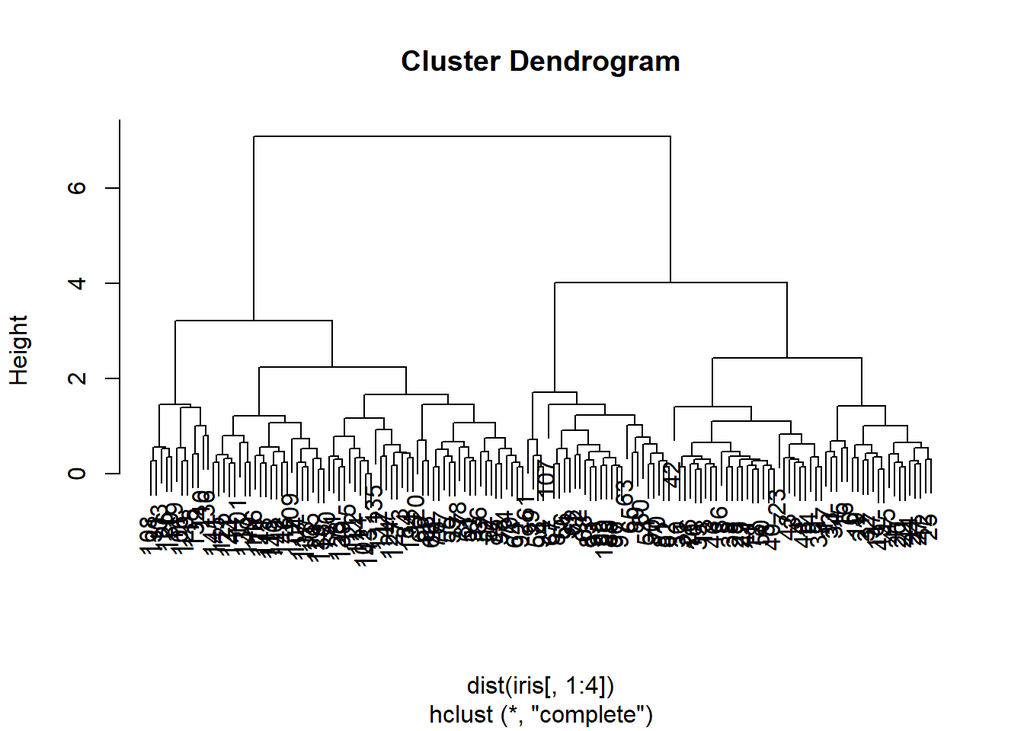

```r
plot(clusters)
```

#### Compare Clusters (Complete Linkage) to Original Species

If we want to get 3 clusters from this data, we will use the `cutree()` function. Then we can see how these resulting clusters line up with the original species.

```r
clusterCut <- cutree(clusters, 3)
table(clusterCut, iris$Species)
```

| clusterCut/ | setosa | versicolor | virginica |
| --- | --- | --- | --- |
| 1 | 50 | 0 | 0 |
| 2 | 0 | 23 | 49 |
| 3 | 0 | 27 | 1 |

#### Cluster Analysis - Average Linkage

Notice that “cluster 2” is not “clean” - it has both versicolor and virginica. Clusters 1 and 3 are pretty good.

Let’s try another linkage method; set method = “average”.

```r
clusters <- hclust(dist(iris[, 3:4]),
                   method = "average")
```

#### Dendogram Cluster Analysis - Average Linkage

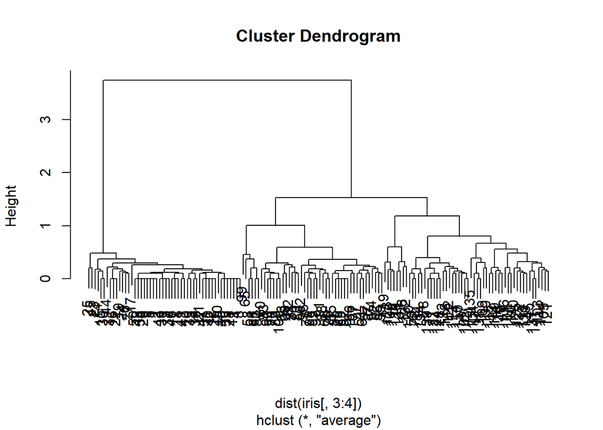

```r
plot(clusters)
```

#### Compare Clusters (Average Linkage) to Original Species

Notice that this “average linkage” method results in clusters that more closely align with the original species. Of course, we don’t usually know what the “correct” answer is (the true cluster designations).

```r
clusterCut <- cutree(clusters, 3)
table(clusterCut, iris$Species)
```

| clusterCut/ | setosa | versicolor | virginica |
| --- | --- | --- | --- |
| 1 | 50 | 0 | 0 |
| 2 | 0 | 45 | 1 |
| 3 | 0 | 5 | 49 |

### Heatmap Approach

The `heatmap()` function is another good visualization tool - you get cluster analyses in 2 dimensions showing the associations between subjects and between variables. So, you can not only get an idea of what clusters and associations exist between the subjects - useful for classifying the subjects or samples in your data - but you can also see what associations exist between the variables.

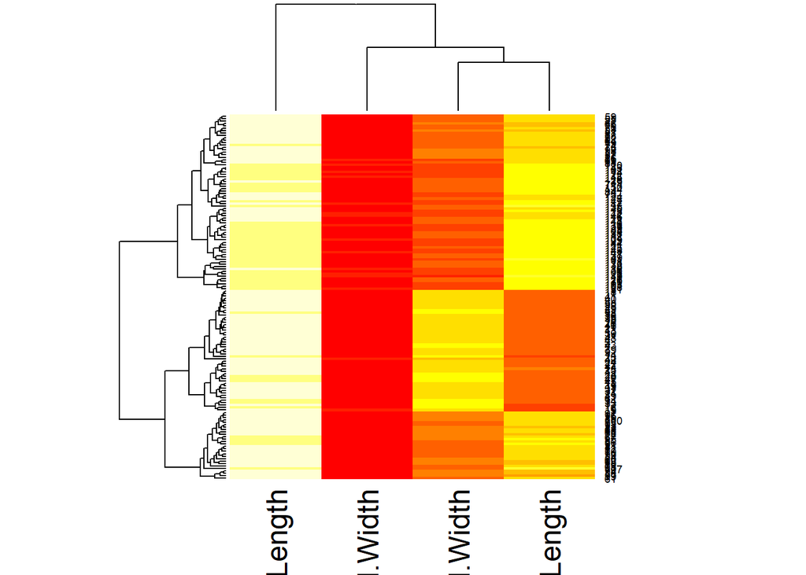

```r
irismatrix <- as.matrix(iris[,1:4])
heatmap(irismatrix)
```

#### Heatmap with updated colors

[figure not shown]

```r
palette <- colorRampPalette(c("green","blue"))(256)
heatmap(irismatrix, Colv=F, scale='none', col=palette)
```

### PCA of IRIS Dataset

Built in to base r (technically in the `stats` package) is the function `princomp()` which will perform Principal Components Analysis or PCA.

PCA basically looks at the matrix of variables and “decomposes” them into “factors” or “components” which are linear combinations of these variables such that they best capture the 1st major component of variability in the data, followed by the 2nd major component of variability in the data and so on until you end up with as many components as variables in the dataset.

#### Run PCA on the `iris` dataset

```r
fit <- princomp(iris[1:4], cor=TRUE)
summary(fit) # print variance accounted for
```

```
## Importance of components:
##                           Comp.1    Comp.2     Comp.3      Comp.4
## Standard deviation     1.7083611 0.9560494 0.38308860 0.143926497
## Proportion of Variance 0.7296245 0.2285076 0.03668922 0.005178709
## Cumulative Proportion  0.7296245 0.9581321 0.99482129 1.000000000
```

```r
loadings(fit) # pc loadings
```

```
##
## Loadings:
##              Comp.1 Comp.2 Comp.3 Comp.4
## Sepal.Length  0.521 -0.377  0.720  0.261
## Sepal.Width  -0.269 -0.923 -0.244 -0.124
## Petal.Length  0.580        -0.142 -0.801
## Petal.Width   0.565        -0.634  0.524
##
##                Comp.1 Comp.2 Comp.3 Comp.4
## SS loadings      1.00   1.00   1.00   1.00
## Proportion Var   0.25   0.25   0.25   0.25
## Cumulative Var   0.25   0.50   0.75   1.00
```

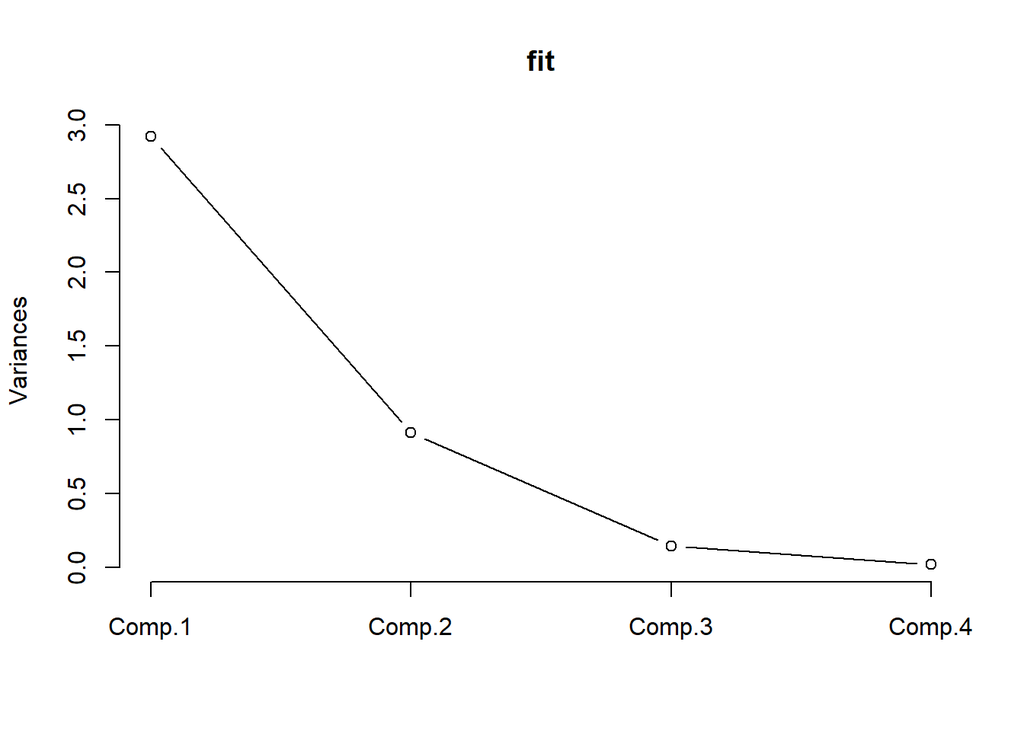

```r
plot(fit,type="lines") # scree plot
```

#### Loadings Plot

Let’s see how the 4 variables “load” onto the 1st 2 principal components

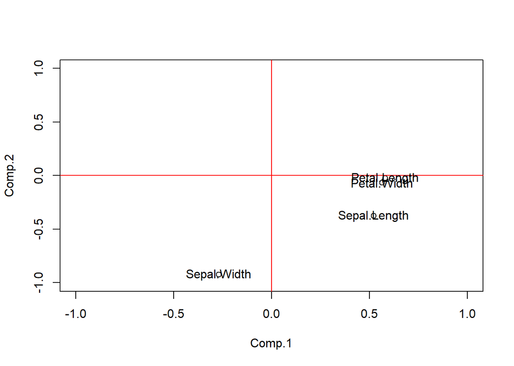

```r
plot(fit[["loadings"]],
     xlim=c(-1,1),ylim=c(-1,1))
abline(h=0, col="red")
abline(v=0, col="red")
text(fit[["loadings"]],
     c("Sepal.Length","Sepal.Width",
       "Petal.Length","Petal.Width"))
```

#### Sample PC Scores

We can also plot the updated “scores” for the first 2 principal components for all 150 samples. These “scores” are the aggregated scores based on the linear combinations of the original variables *(e.g. using the weights or loadings listed above)*.

```r
head(fit$scores) # top listing of the sample scores for all 4 principal components
```

| Comp.1 | Comp.2 | Comp.3 | Comp.4 |
| --- | --- | --- | --- |
| -2.264703 | -0.4800266 | 0.1277060 | 0.0241682 |
| -2.080961 | 0.6741336 | 0.2346089 | 0.1030068 |
| -2.364229 | 0.3419080 | -0.0442015 | 0.0283771 |
| -2.299384 | 0.5973945 | -0.0912901 | -0.0659556 |
| -2.389842 | -0.6468354 | -0.0157382 | -0.0359228 |
| -2.075631 | -1.4891775 | -0.0269683 | 0.0066082 |

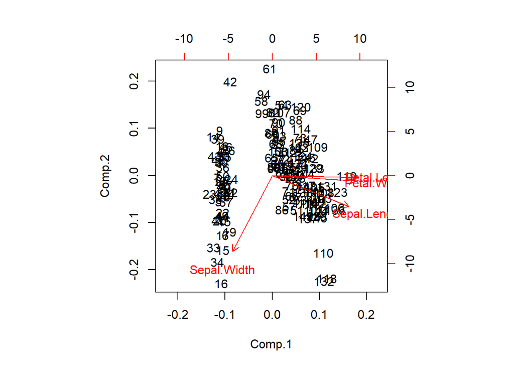

```r
biplot(fit) # plot samples on PC1 and PC2
```

### If Time - Demo `GGobi`

There is a really good visualization tool/software called “GGobi”. You can learn more at http://www.ggobi.org/.

If you would like to install “GGobi”, see the instructions at http://www.ggobi.org/downloads/.

Once you get everything installed, then install the `rggobi` R package.

Here is some code to get you started. You can run this code from an R script inside RStudio to see how it works interactively.

```
library(rggobi)

# View iris dataset - use KNOWN species to color
g <- ggobi(iris)
glyph_colour(g[1]) <- as.numeric(iris$Species)

# View iris dataset - use Cluster Analysis
# unsupervised clusters to color
g <- ggobi(iris)
clustering <- hclust(dist(iris[,1:4]),
                     method="average")
glyph_colour(g[1]) <- cutree(clustering, 3)
```